# survey experiments

Macartan Humphreys

## 1 Survey experiments

- Survey experiments are used to *measure* things: nothing (except answers) should be *changed*!
- If the experiment in the survey is changing things then it is a field experiment in a survey, not a survey experiment

### 1.1 The list experiment: Motivation

- Multiple survey experimental designs have been generated to make it easier for subjects to answer **sensitive questions**
- The key idea is to use inference rather than measurement.
- Subjects are placed in different conditions and the conditions *affect* the **answers** that are given in such a way that you can infer some underlying quantity of interest

### 1.2 The list experiment: Motivation

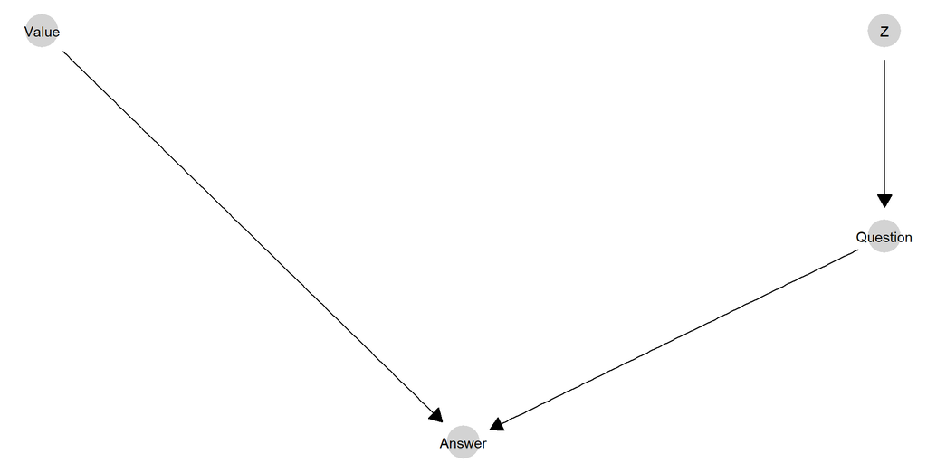

This is an obvious DAG but the main point is to be clear that the *Value* is the quantity of interest and the value is not affected by the treatment, *Z*.

### 1.3 The list experiment: Motivation

The list experiment supposes that:

1. Subjects do not want to give a direct answer to a question
2. They nevertheless are willing to truthfully answer an indirect question

**In other words**: sensitivities notwithstanding, *they are happy for the researcher to make correct inferences about them or their group*

### 1.4 The list experiment: Strategy

- Respondents are given a short list and a long list.
- The long list differs from the short list in having *one extra item*—the sensitive item
- We ask how many items in each list does a respondent agree with:
  - $Y_i(0)$ is the number of elements on a short list that a respondent agrees with
  - $Y_i(1)$ is the number of elements on a long list that a respondent agrees with
  - $Y_i(1) - Y_i(0)$ is an indicator for whether an individual agrees with the sensitive item
  - $\mathbb{E}[Y_i(1) - Y_i(0)]$ is the share of people agreeing with sensitive item

### 1.5 The list experiment: Simplified example

How many of these do you agree with:

[output not shown]

[Note: this is obviously not a good list. Why not?]

### 1.6 The list experiment: Design

```r
declaration_17.3 <-
  declare_model(
    N = 500,
    control_count = rbinom(N, size = 3, prob = 0.5),
    Y_star = rbinom(N, size = 1, prob = 0.3),
    potential_outcomes(Y_list ~ Y_star * Z + control_count)
  ) +
  declare_inquiry(prevalence_rate = mean(Y_star)) +
  declare_assignment(Z = complete_ra(N)) +
  declare_measurement(Y_list = reveal_outcomes(Y_list ~ Z)) +
  declare_estimator(Y_list ~ Z, .method = difference_in_means,
                    inquiry = "prevalence_rate")

diagnosands <- declare_diagnosands(
  bias = mean(estimate - estimand),
  mean_CI_width = mean(conf.high - conf.low)
)
```

### 1.7 Diagnosis

```r
diagnose_design(declaration_17.3, diagnosands = diagnosands)
```

[output not shown]

### 1.8 Tradeoffs: is the question really sensitive?

```r
declaration_17.4 <-
  declare_model(
    N = N,
    U = rnorm(N),
    control_count = rbinom(N, size = 3, prob = 0.5),
    Y_star = rbinom(N, size = 1, prob = 0.3),
    W = case_when(Y_star == 0 ~ 0L,
                  Y_star == 1 ~ rbinom(N, size = 1, prob = proportion_hiding)),
    potential_outcomes(Y_list ~ Y_star * Z + control_count)
  ) +
  declare_inquiry(prevalence_rate = mean(Y_star)) +
  declare_assignment(Z = complete_ra(N)) +
  declare_measurement(Y_list = reveal_outcomes(Y_list ~ Z),
                      Y_direct = Y_star - W) +
  declare_estimator(Y_list ~ Z, inquiry = "prevalence_rate", label = "list") +
  declare_estimator(Y_direct ~ 1, inquiry = "prevalence_rate", label = "direct")
```

### 1.9 Diagnosis

```r
declaration_17.4 |>
  redesign(proportion_hiding = seq(from = 0, to = 0.3, by = 0.1),
           N = seq(from = 500, to = 2500, by = 500)) |>
  diagnose_design()
```

[output not shown]

### 1.10 Negatively correlated items

- How would estimates be affected if the items selected for the list were *negatively* correlated?
- How would subject protection be affected?

### 1.11 Negatively correlated items

```r
rho <- -.8

correlated_lists <-
  declare_model(
    N = 500,
    U = rnorm(N),
    control_1 = rbinom(N, size = 1, prob = 0.5),
    control_2 = correlate(given = control_1, rho = rho, draw_binary, prob = 0.5),
    control_count = control_1 + control_2,
    Y_star = rbinom(N, size = 1, prob = 0.3),
    potential_outcomes(Y_list ~ Y_star * Z + control_count)
  ) +
  declare_inquiry(prevalence_rate = mean(Y_star)) +
  declare_assignment(Z = complete_ra(N)) +
  declare_measurement(Y_list = reveal_outcomes(Y_list ~ Z)) +
  declare_estimator(Y_list ~ Z)
```

### 1.12 Negatively correlated items

```r
draw_data(correlated_lists) |> ggplot(aes(control_count)) +
  geom_histogram() + theme_bw()
```

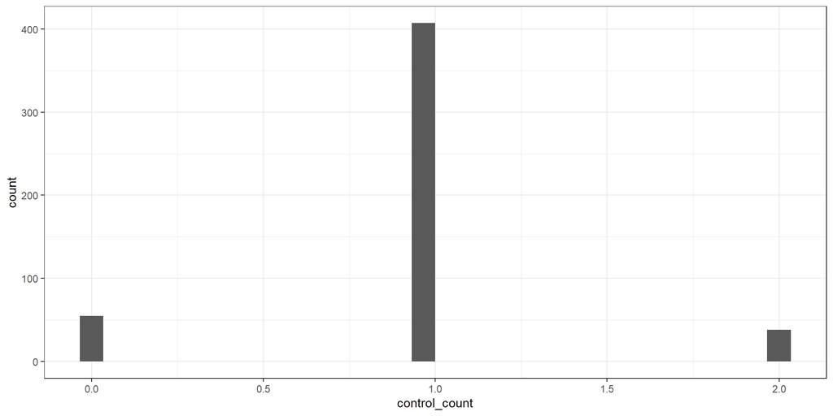

### 1.13 Negatively correlated items

```r
correlated_lists |> redesign(rho = c(-.8, 0, .8)) |> diagnose_design()
```

[output not shown]

### 1.14 Individual or group effects?

- This is typically used to estimate average *levels*
- However you *can* use it in the obvious way to get average levels for groups: this is equivalent to calculating group level heterogeneous effects
- Extending the idea you can even get *individual level* estimates: for instance you might use causal forests
- You can also use this to estimate the *effect* of an experimental treatment on an item that’s measured using a list, without requiring individual level estimates:

$$Y_i = \beta_0 + \beta_1Z_i + \beta_2Long_i + \beta_3Z_iLong_i$$

### 1.15 Hiders and liars

- Note that here we looked at “hiders” – people not answering the direct question truthfully
- See Li (2019) on bounds when the “no liars” assumption is threatened — this is about whether people respond truthfully to the list experimental question

Li, Yimeng. 2019. “Relaxing the No Liars Assumption in List Experiment Analyses.” *Political Analysis* 27 (4): 540–55.